# diversity indices

Genome-wide association mapping reveals a rich genetic architecture of complex traits in Oryza sativa

Author

Fernando Chuquizuta Chavez, Anderson Villacrez Arce, Elder Antonio Quispe Aguilar

# 1 Project Setup

```
Project:  C:/Users/USUARIO/Desktop/Nueva carpeta (2)
```

# 2 References

- https://www.nature.com/articles/s41576-024-00738-6
- https://github.com/ChristieLab/filtering_simulation_paper
- https://github.com/hemstrow/snpR

# 3 snpR Introduction

snpR is a SNP genomic analysis package that is designed to do a range of basic genomic analyses, such as calculate observed and expected heterozygosity, linkage disequilibrium, pairwise-Fst, and so on. This package also has dimensionality reduction tools (eg. PCA), data formatting conversions for other packages and programs, population structure, genetic prediction, private allele detection and more.

# 4 Quick-start Guide

# 5 Import data

Genotypes are noted with two characters, such as “GG” or “GA” for a G/G homozygote and a G/A heterozygote, respectively. The missing data format can be user-defined, but is “NN” by default.

## 5.1 Meta data

## 5.2 snpRdata objects and facets

```
##     081215-A05_1 081215-A06_3 081215-A07_4 081215-A08_5 090414-A09_6
## 1             GG           NN           GG           GG           NN
## 2             TT           CC           CC           CC           CC
## 3             AA           TT           AA           TT           AA
## 4             TT           CC           CC           CC           CC
## 5             TT           CC           CC           CC           CC
## 6             AA           GG           AA           GG           AA
## 7             TT           CC           CC           CC           CC
## 8             GG           AA           GG           AA           GG
## 9             TT           CC           CC           TT           CC
## 10            CC           CC           TT           CC           CC
## 11            AA           CC           AA           AA           AA
## 12            AA           GG           AA           AA           AA
## 13            GG           AA           GG           NN           GG
## 14            CC           CC           CC           TT           CC
```

[output cut: 45211 more lines]

## 5.3 statistics

| facet | subfacet | chr | position | .snp.id | ho |
| --- | --- | --- | --- | --- | --- |
| .base | .base | 11 | 3571 | 1 | 0.0000000 |
| .base | .base | 8 | 6348 | 2 | 0.0000000 |
| .base | .base | 2 | 8515 | 3 | 0.0000000 |
| .base | .base | 2 | 9619 | 4 | 0.0000000 |
| .base | .base | 1 | 13147 | 5 | 0.0000000 |
| .base | .base | 2 | 15048 | 6 | 0.0000000 |
| .base | .base | 7 | 15195 | 7 | 0.0024331 |
| .base | .base | 2 | 15846 | 8 | 0.0000000 |
| .base | .base | 7 | 18107 | 9 | 0.0000000 |
| .base | .base | 7 | 22647 | 10 | 0.0000000 |
| .base | .base | 8 | 29078 | 11 | 0.0024331 |
| .base | .base | 8 | 31728 | 12 | 0.0000000 |
| .base | .base | 8 | 33534 | 13 | 0.0000000 |
| .base | .base | 8 | 33606 | 14 | 0.0000000 |
| .base | .base | 8 | 36046 | 15 | 0.0048426 |
| .base | .base | 5 | 39451 | 16 | 0.0000000 |
| .base | .base | 5 | 40128 | 17 | 0.0000000 |
| .base | .base | 7 | 41342 | 18 | 0.0000000 |
| .base | .base | 5 | 41995 | 19 | 0.0000000 |
| .base | .base | 2 | 42076 | 20 | 0.0000000 |
| .base | .base | 8 | 42414 | 21 | 0.0048426 |
| .base | .base | 7 | 44171 | 22 | 0.0000000 |
| .base | .base | 5 | 44370 | 23 | 0.0000000 |
| .base | .base | 5 | 44806 | 24 | 0.0000000 |
| .base | .base | 8 | 51045 | 25 | 0.0000000 |
| .base | .base | 4 | 58946 | 26 | 0.0000000 |
| .base | .base | 5 | 62107 | 27 | 0.0000000 |
| .base | .base | 8 | 63899 | 28 | 0.0000000 |
| .base | .base | 10 | 64322 | 29 | 0.0024272 |
| .base | .base | 5 | 65465 | 30 | 0.0000000 |

[output cut: 36871 more lines]

| facet | subfacet | snp.facet | snp.subfacet | weighted_mean_ho |
| --- | --- | --- | --- | --- |
| .base | .base | .base | .base | 0.0004122 |

### 5.3.1 Facets

Facets are a fundamental feature of snpR. Often, SNP data must be separated by population/chromosome/family/year etc. before statistics are calculated. Additionally, many statistics, like Fst, need to be calculated *pairwise* by comparing each population to every other population. Facets allow you to easily do this without the need for direct data manipulation.

```
##   facet subfacet snp.facet snp.subfacet weighted_mean_ho
## 1   pop    ADMIX     .base        .base    0.00076364331
## 2   pop AROMATIC     .base        .base    0.00006888238
## 3   pop      AUS     .base        .base    0.00026389949
## 4   pop      IND     .base        .base    0.00072128485
## 5   pop      TEJ     .base        .base    0.00039799838
## 6   pop      TRJ     .base        .base    0.00006169823
```

### 5.3.2 Complex Facets

```
##      facet   subfacet snp.facet snp.subfacet weighted_mean_ho
## 1  fam.pop    A.ADMIX     .base        .base    0.00003963293
## 2  fam.pop A.AROMATIC     .base        .base    0.00006028067
## 3  fam.pop      A.AUS     .base        .base    0.00010389926
## 4  fam.pop      A.IND     .base        .base    0.00005312455
## 5  fam.pop      A.TEJ     .base        .base    0.00090451020
## 6  fam.pop      A.TRJ     .base        .base    0.00006916896
## 7  fam.pop    B.ADMIX     .base        .base    0.00003591988
## 8  fam.pop B.AROMATIC     .base        .base    0.00011261261
## 9  fam.pop      B.AUS     .base        .base    0.00003742487
## 10 fam.pop      B.IND     .base        .base    0.00184826788
## 11 fam.pop      B.TEJ     .base        .base    0.00013180519
## 12 fam.pop      B.TRJ     .base        .base    0.00007200835
## 13 fam.pop    C.ADMIX     .base        .base    0.00413230616
## 14 fam.pop C.AROMATIC     .base        .base    0.00007881308
## 15 fam.pop      C.AUS     .base        .base    0.00082279190
## 16 fam.pop      C.IND     .base        .base    0.00104838213
## 17 fam.pop      C.TEJ     .base        .base    0.00014537046
## 18 fam.pop      C.TRJ     .base        .base    0.00005605009
## 19 fam.pop    D.ADMIX     .base        .base    0.00005994802
## 20 fam.pop D.AROMATIC     .base        .base    0.00006497545
## 21 fam.pop      D.AUS     .base        .base    0.00005868858
## 22 fam.pop      D.IND     .base        .base    0.00007763818
## 23 fam.pop      D.TEJ     .base        .base    0.00045508051
## 24 fam.pop      D.TRJ     .base        .base    0.00005178979
```

## 5.4 SNP filtering

The `filter_snps()` function can be used to filter poorly sequenced individuals and loci, remove SNPs with a low minor allele frequency either overall or by facet (often population), remove highly heterozygous SNPs (which are likely sourced from duplicated genomic regions), and remove non-biallelic SNPs.

We will filter out all loci with a minor allele frequency below 0.05 in all populations, loci with a heterozygote frequency above 0.55, that are not bi-allelic, that are non-polymorphic, or that are sequenced in less than half of the individuals. We will also remove all individuals that are genotyped at less than half of the remaining loci, then quickly re-check that all loci are still polymorphic.

```
## Initializing...
## Filtering loci. Starting loci: 36901
## Filtering non-biallelic loci...
##  0 bad loci
## Filtering non_polymorphic loci...
##  0 bad loci
## Filtering loci sequenced in few individuals...
##  0 bad loci
## Filtering low minor allele frequencies by facet.
##  708 bad loci
## Filtering high frequency heterozygote loci...
##  0 bad loci
##  Ending loci: 36193
## Filtering individuals. Starting individuals: 413
## Filtering out individuals sequenced in few kept loci...
## No individuals removed.
## Re-filtering loci...
## Filtering non_polymorphic loci...
##  0 bad loci
##  Final loci count: 36193
```

## 5.5 PCA plots

A common first analytical step for new data is to run a PCA to look for any evidence of population structure/sequencing errors.

[output not shown]

[output cut: 20490 more lines]

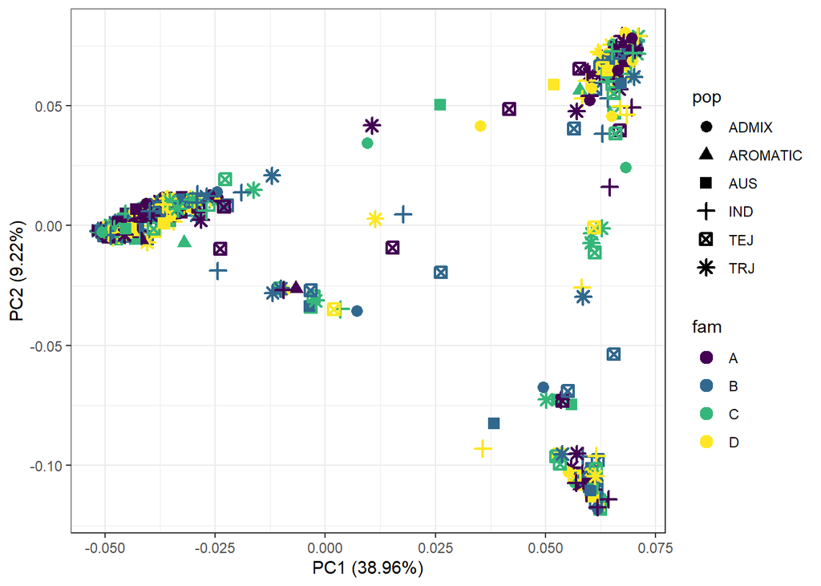

```
##
##
## $pca_loadings
##   [1] 38.96  9.22  6.74  2.30  1.49  1.28  1.06  0.88  0.84  0.70  0.64  0.64
##  [13]  0.58  0.56  0.53  0.46  0.46  0.43  0.42  0.38  0.37  0.37  0.35  0.34
##  [25]  0.33  0.32  0.32  0.30  0.29  0.29  0.29  0.28  0.28  0.28  0.27  0.26
##  [37]  0.26  0.25  0.25  0.24  0.24  0.24  0.24  0.23  0.23  0.23  0.22  0.22
##  [49]  0.22  0.21  0.21  0.21  0.20  0.20  0.20  0.20  0.20  0.19  0.19  0.19
##  [61]  0.19  0.19  0.18  0.18  0.18  0.18  0.18  0.17  0.17  0.17  0.17  0.17
##  [73]  0.17  0.16  0.16  0.16  0.16  0.16  0.16  0.16  0.15  0.15  0.15  0.15
##  [85]  0.15  0.14  0.14  0.14  0.14  0.14  0.14  0.14  0.14  0.14  0.14  0.14
##  [97]  0.13  0.13  0.13  0.13  0.13  0.13  0.13  0.13  0.12  0.12  0.12  0.12
## [109]  0.12  0.12  0.12  0.12  0.12  0.12  0.12  0.12  0.12  0.11  0.11  0.11
## [121]  0.11  0.11  0.11  0.11  0.11  0.11  0.11  0.11  0.11  0.10  0.10  0.10
## [133]  0.10  0.10  0.10  0.10  0.10  0.10  0.10  0.10  0.10  0.10  0.10  0.09
```

[output cut: 23 more lines]

## 5.6 Calculate minor allele frequencies, $\pi$, Ho, check for private alleles and HWE.

Minor allele frequencies, $\pi$, Ho, and HWE divergence, and other basic diversity statistics are easy to calculate with snpR.

```
## $single
##      facet subfacet chr position .snp.id        maf maj.count major min.count
## 1      pop    ADMIX  11     3571       1 0.27659575        68     G        26
## 2      pop AROMATIC  11     3571       1 0.33333333        16     G         8
## 3      pop      AUS  11     3571       1 0.19047619        68     G        16
## 4      pop      IND  11     3571       1 0.35616438        94     G        52
## 5      pop      TEJ  11     3571       1 0.32941177       114     G        56
## 6      pop      TRJ  11     3571       1 0.28571429       110     G        44
## 7      pop    ADMIX   8     6348       2 0.36842105        72     C        42
## 8      pop AROMATIC   8     6348       2 0.35714286        18     C        10
## 9      pop      AUS   8     6348       2 0.38775510        60     C        38
## 10     pop      IND   8     6348       2 0.42105263        88     C        64
## 11     pop      TEJ   8     6348       2 0.31460674       122     C        56
## 12     pop      TRJ   8     6348       2 0.44705882        94     C        76
## 13     pop    ADMIX   2     8515       3 0.20967742        98     A        26
```

[output cut: 25003 more lines]

## 5.7 Pairwise Fst calculation

snpR can calculate pairwise Fst using a few approaches. Here, we’ll use Wier and Cockerham (1984)’s method to calculate pairwise Fst between each pair of populations for each SNP.

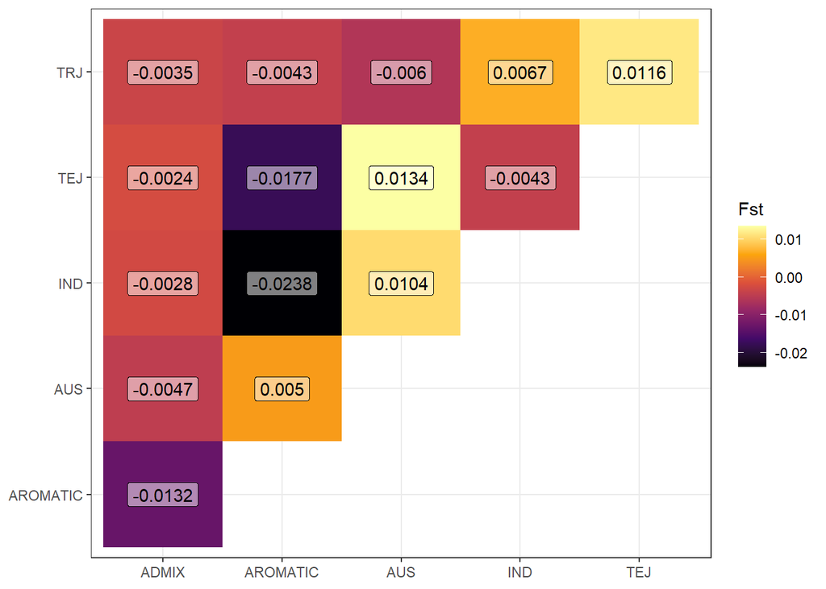

To recover the data, we again use get.snpR.stats. We get a new kind of output here: fst.matrix, which will show a matrix of fst scores across comparisons!

| p1 | AROMATIC | AUS | IND | TEJ | TRJ |
| --- | --- | --- | --- | --- | --- |
| ADMIX | -0.0131565 | -0.0046928 | -0.0027517 | -0.0023649 | -0.0035273 |
| AROMATIC |  | 0.0050057 | -0.0238120 | -0.0176863 | -0.0042814 |
| AUS |  |  | 0.0104468 | 0.0134362 | -0.0060044 |
| IND |  |  |  | -0.0042858 | 0.0067127 |
| TEJ |  |  |  |  | 0.0115536 |

# 6 Easy mode

Most of the statistics above can be calculated in one step!

This will calculate $\pi$, Ho, HWE, mafs, private alleles, and pairwise Fst, and calculate smoothed windows for these stats in one easy step.

```
## $single
##       facet subfacet chr position .snp.id         pi
## 1       pop    ADMIX  11     3571       1 0.40448410
## 2       pop AROMATIC  11     3571       1 0.46376812
## 3       pop      AUS  11     3571       1 0.31210557
## 4       pop      IND  11     3571       1 0.46178555
## 5       pop      TEJ  11     3571       1 0.44441351
## 6       pop      TRJ  11     3571       1 0.41083100
## 7       pop    ADMIX   8     6348       2 0.46949231
## 8       pop AROMATIC   8     6348       2 0.47619048
## 9       pop      AUS   8     6348       2 0.47969703
## 10      pop      IND   8     6348       2 0.49076333
## 11      pop      TEJ   8     6348       2 0.43369517
## 12      pop      TRJ   8     6348       2 0.49731987
## 13      pop    ADMIX   2     8515       3 0.33412012
```

[output cut: 33400 more lines]

## 6.1 Plot the Smoothed Parameters

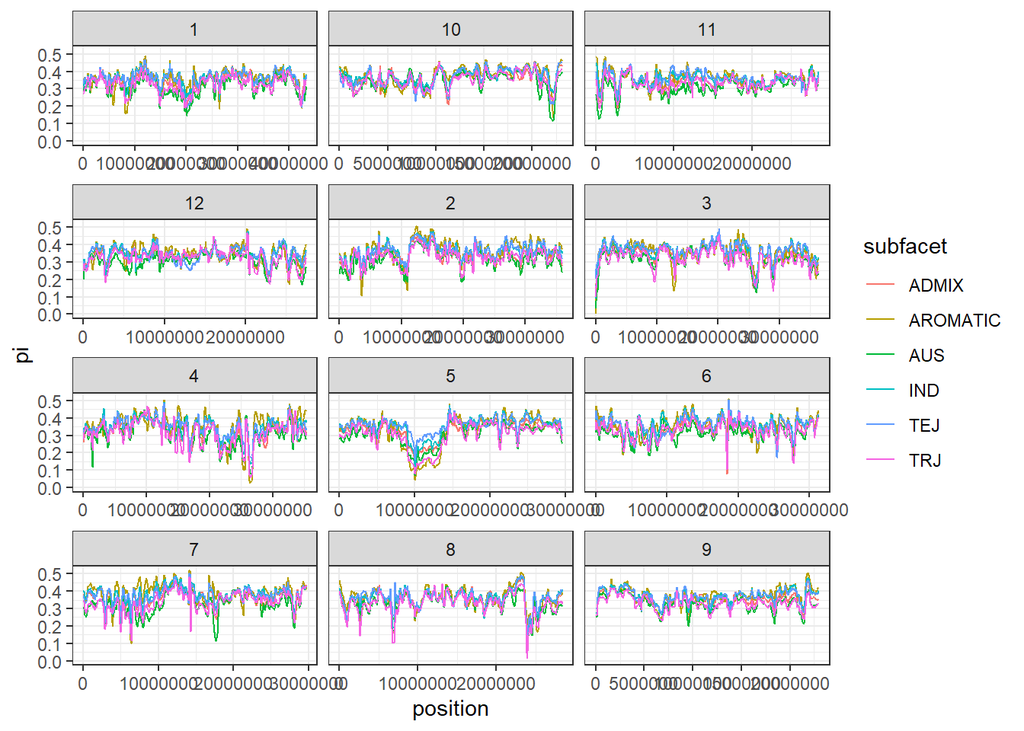